# **Evaluación de modelos para la predicción mensual de accidentes viales con Gravedad: Heridos**

Alexis A. Arenas Bustamante, Juan E. Arroyave Duque, William A. Jovel Tamayo, Manuela Londoño Ocampo.* Curso de Analítica Predictiva Universidad Nacional de Colombia Facultad de Minas Medellín

Septiembre de 2019

# 1 **Librerías Necesarias**

```r
library(dplyr) # data wrangling
library(ranger)
library(caret)
library(corrplot)
library(rsample)     # data splitting
library(rpart)       # performing regression trees
library(rpart.plot)  # plotting regression trees
library(ipred)       # bagging
require(MASS)
library(randomForest)
library(tidyverse)
library(ggpubr)
```

Se consideran tres modelos para la predicción mensual de los accidentes viales con heridos: Regresión lineal, Árbol de regresión y Random Forest. A continuación se presenta la evaluación de cada uno:

# 2 **Dataset propuesto para el modelo mensual de accidentalidad vial : Heridos**

```r
datos_mensualesH <- read.csv("~/Docs/MAESTRIA/ANALITICA PREDICTIVA/Trabajo Final/Datasets/RAPIDM/mensual_h_2.csv", sep=",")

head(datos_mensualesH)
```

|  | PERIODO | MES | SEMANA | FESTIVOS | HERIDOS |
| --- | --- | --- | --- | --- | --- |
| 1 | 2014 | 1 | 1 | 1 | 85 |
| 2 | 2014 | 1 | 1 | 0 | 222 |
| 3 | 2014 | 1 | 2 | 0 | 342 |
| 4 | 2014 | 1 | 3 | 0 | 391 |
| 5 | 2014 | 1 | 4 | 0 | 421 |
| 6 | 2014 | 1 | 5 | 0 | 174 |

# 3 **Estadísticas Descriptivas**

## 3.1 **Summary del conjunto de datos**

```
##     PERIODO          MES             SEMANA         FESTIVOS
##  Min.   :2014   Min.   : 1.000   Min.   : 1.00   Min.   :0.0000
##  1st Qu.:2015   1st Qu.: 4.000   1st Qu.:14.00   1st Qu.:0.0000
##  Median :2016   Median : 7.000   Median :26.00   Median :0.0000
##  Mean   :2016   Mean   : 6.618   Mean   :26.93   Mean   :0.2136
##  3rd Qu.:2017   3rd Qu.:10.000   3rd Qu.:40.75   3rd Qu.:0.0000
##  Max.   :2018   Max.   :12.000   Max.   :53.00   Max.   :1.0000
##     HERIDOS
##  Min.   : 26.0
##  1st Qu.:103.0
##  Median :341.0
##  Mean   :293.7
##  3rd Qu.:448.8
##  Max.   :545.0
```

## 3.2 **Histograma de la variable dependiente**

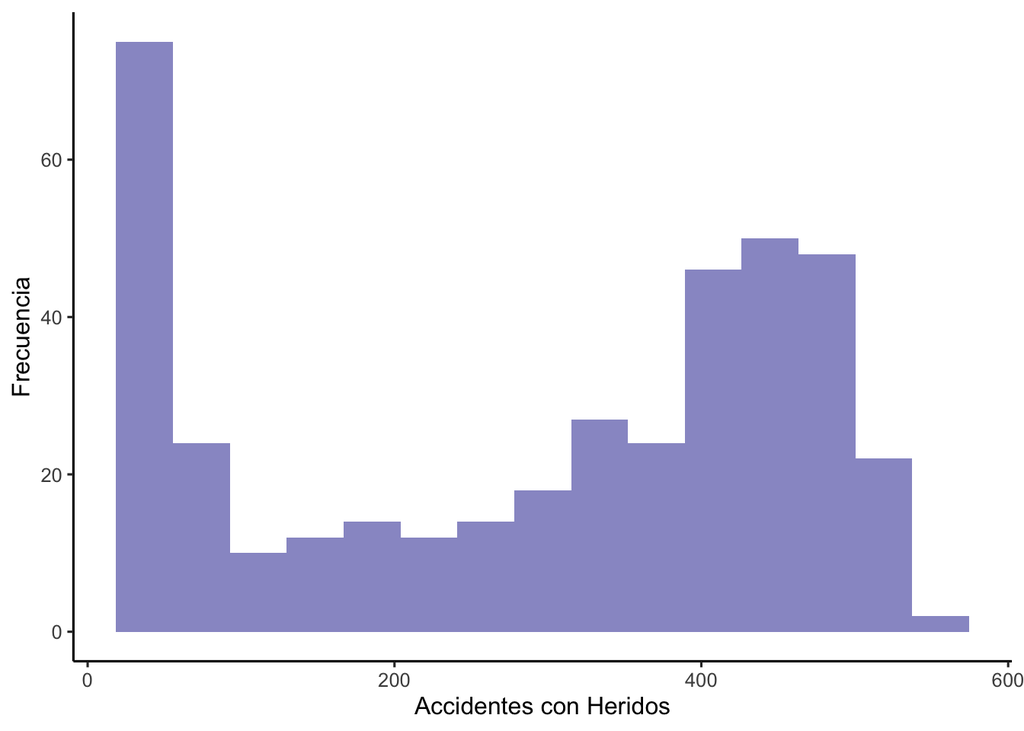

## 3.3 **Boxplots por mes**

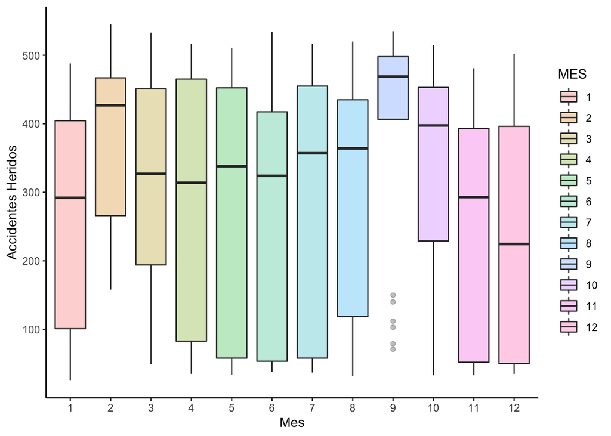

Se puede observar la presencia de ciertos valores atípicos por mes. Estos se trataran por medio de la imputación con mediana.

## 3.4 **Correlación entre variables consideradas**

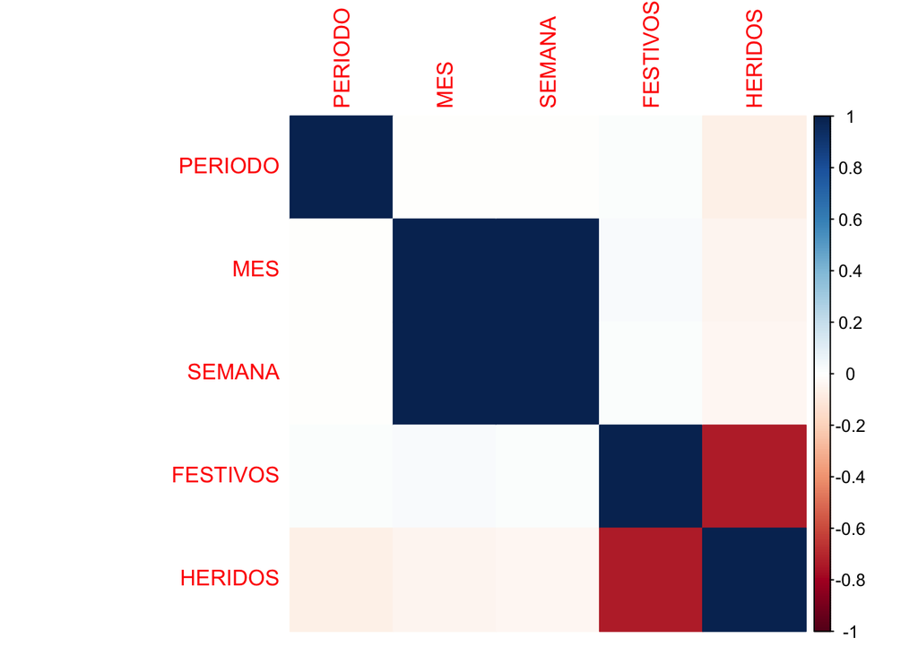

Se puede observar que la variable mas correlacionada con la cantidad de accidentes mensuales con heridos es FESTIVOS. En cada uno de los modelos propuestos se identificará la importancia de las variables, de modo que solo se incluyan aquellas que tengan una influencia significativa sobre la variables dependiente. El periodo no hará parte de ningún modelo puesto que solo se usa para la partición de los datos en conjuntos de entrenamiento y validación.

## 3.5 **Evaluación y tratamiento de atípicos**

Se define una función para la identificación e imputación de los valores atípicos basado en el rango intercuartil. Se realiza la imputación con la mediana.

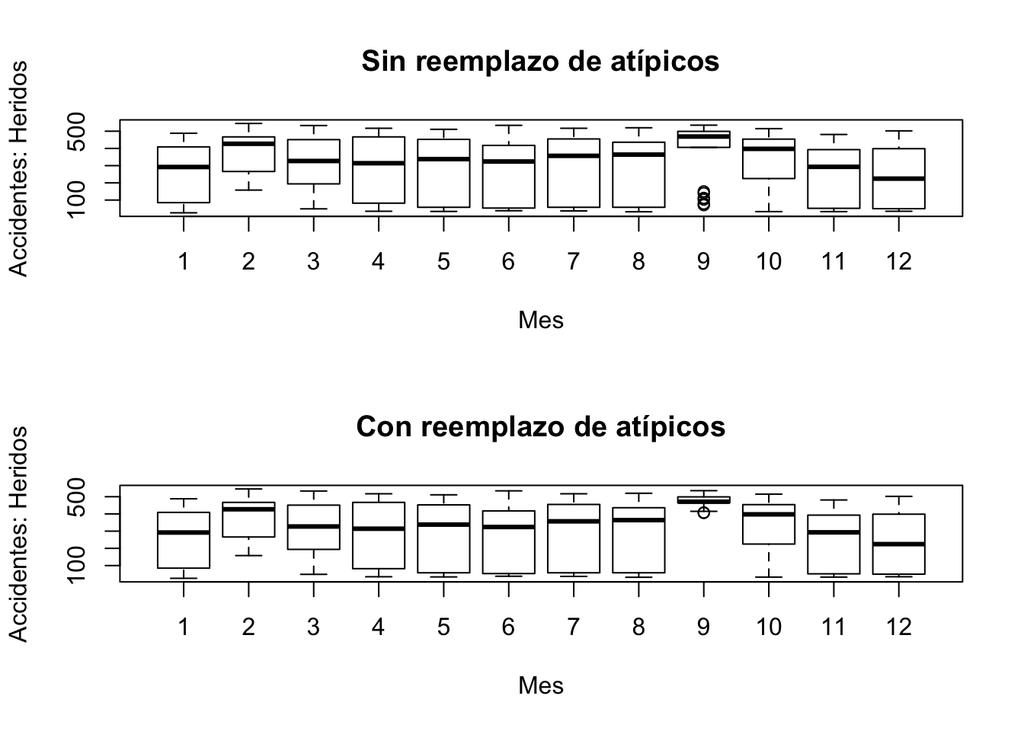

# 4 **Partición de los datos conjuntos de train y test**

Para la validación se usaran los datos de accidentes viales ocurridos en el año 2018.

Datos de Train: Se cuenta 318 observaciones para el entrenamiento de los modelos

```
## [1] 318   5
```

Datos de Test: Se cuenta con 80 observaciones para la validación de los modelos

```r
dim(heridos_test)
```

```
## [1] 80  5
```

Una vez realizada la partición de los datos, se procede con la eliminación de la variable PERIODO en ambos datasets.

```r
heridos_train <- dplyr :: select(heridos_train, -PERIODO)
heridos_test <- dplyr :: select(heridos_test, -PERIODO)
```

# 5 **Modelo de predicción considerados**

## 5.1 **Regresión Lineal**

**Entrenamiento del modelo**

```r
heridos_train$SEMANA <- as.factor(heridos_train$SEMANA)

regresion_1 <- lm(HERIDOS.R ~., data = heridos_train)

summary(regresion_1)
```

```
##
## Call:
## lm(formula = HERIDOS.R ~ ., data = heridos_train)
##
## Residuals:
##      Min       1Q   Median       3Q      Max
## -188.070  -25.891   -0.618   24.789  161.169
##
## Coefficients:
##             Estimate Std. Error t value Pr(>|t|)
## (Intercept)  331.105     18.266  18.126  < 2e-16 ***
## MES2         104.000     35.651   2.917 0.003850 **
## MES3         136.000     50.418   2.697 0.007458 **
## MES4        -160.570     61.807  -2.598 0.009929 **
## MES5         111.285     69.051   1.612 0.108288
## MES6          40.590     75.488   0.538 0.591252
## MES7        -242.813     83.517  -2.907 0.003968 **
## MES8         -24.813     90.808  -0.273 0.784885
## MES9          82.187     97.556   0.842 0.400326
## MES10         62.687    112.670   0.556 0.578447
## MES11        115.257    117.252   0.983 0.326555
## MES12       -109.743    122.553  -0.895 0.371384
## SEMANA2       17.985     26.100   0.689 0.491409
## SEMANA3      117.645     31.131   3.779 0.000196 ***
## SEMANA4       98.895     31.131   3.177 0.001675 **
## SEMANA5     -157.355     31.131  -5.055 8.28e-07 ***
## SEMANA6       67.145     47.330   1.419 0.157236
## SEMANA7       17.145     47.330   0.362 0.717480
## SEMANA8       53.395     47.330   1.128 0.260336
## SEMANA9     -215.105     47.330  -4.545 8.53e-06 ***
## SEMANA10      27.895     59.255   0.471 0.638222
## SEMANA11      30.645     59.255   0.517 0.605493
## SEMANA12     -79.500     56.369  -1.410 0.159668
## SEMANA13     -90.535     57.317  -1.580 0.115457
## SEMANA14     248.707     68.112   3.651 0.000317 ***
## SEMANA15     239.535     67.500   3.549 0.000461 ***
## SEMANA16     228.368     67.500   3.383 0.000830 ***
## SEMANA17     307.715     69.051   4.456 1.25e-05 ***
## SEMANA18     -88.535     69.051  -1.282 0.200957
## SEMANA19       2.452     74.875   0.033 0.973905
```

[output cut: 26 more lines]

```
## SEMANA46     -62.632    119.932  -0.522 0.601967
## SEMANA47       6.388    121.324   0.053 0.958053
## SEMANA48    -108.112    121.324  -0.891 0.373718
## SEMANA49     156.743    125.119   1.253 0.211451
## SEMANA50     205.638    126.453   1.626 0.105153
## SEMANA51     250.888    126.453   1.984 0.048333 *
## SEMANA52     137.368    125.119   1.098 0.273291
## SEMANA53    -152.362    126.453  -1.205 0.229371
## FESTIVOS    -324.211      7.978 -40.640  < 2e-16 ***
## ---
## Signif. codes:  0 '***' 0.001 '**' 0.01 '*' 0.05 '.' 0.1 ' ' 1
##
## Residual standard error: 50.42 on 253 degrees of freedom
## Multiple R-squared:  0.9328, Adjusted R-squared:  0.9158
## F-statistic: 54.86 on 64 and 253 DF,  p-value: < 2.2e-16
```

Las variables MES y SEMANA se incluyeron en el modelo de regresión lineal como factores, vemos ademas, que algunas de las variables incluidad no son significativas para el modelo, pero según el summary se obtuvo un buen R-squared, que explica el 93.28 % de la accidentalidad mensual con gravedad de heridos. De igual manera el valor P del estadístico F es significativo.

**Métricas de Bondad para regresión lineal**

| RMSE_Train | Rsquared_Train | RMSE_Test | Rsquared_Test |
| --- | --- | --- | --- |
| 44.97134 | 0.9327798 | 61.25516 | 0.9143525 |

Comparando las métricas consideradas tanto para el entrenamiento como para la validación del modelo, observamos que en ambos se obtiene un -squared bueno, superior al 90%. Adicionalmente la variación entre los RMSE es del 36.20%, esta variación es alta, lo que puede indicar sobre entrenamiento.

**Ajuste de las predicciones vs valores reales**

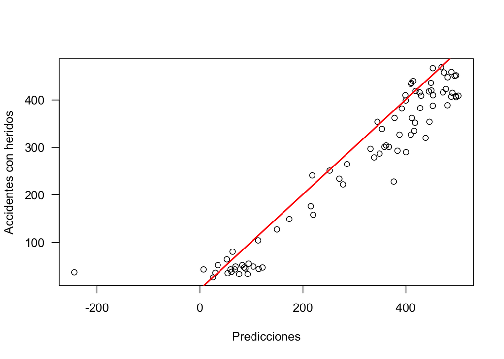

```r
plot(y_pred_test_h, heridos_test$HERIDOS.R ,las=1, xlab="Predicciones", ylab = "Accidentes con heridos")
abline(a=1,b=1,lwd=2,col="red")
```

En el gráfico de dispersión se puede observar que el modelo presenta mejor capacidad de predicción para valores bajos que para valores altos de accidentalidad mensual.

## 5.2 **Árbol Regresor**

**Entrenamiento del modelo**

Se toma el modelo mas simple para el árbol regresor, a partir de este se realizará una búsqueda tipo **grid search** de los parámetros de restricción óptimos. Se definen ademas funciones para extraer el mínimo error asociado con el valor óptimo de costo de complejidad (CP) de cada modelo y el valor óptimo CP.

```r
set.seed(123)
dt_h <- rpart(
  formula = HERIDOS.R ~ .,
  data    = heridos_train,
  method  = "anova"
  )
```

**Representación gráfica del árbol regresor sin tuning**

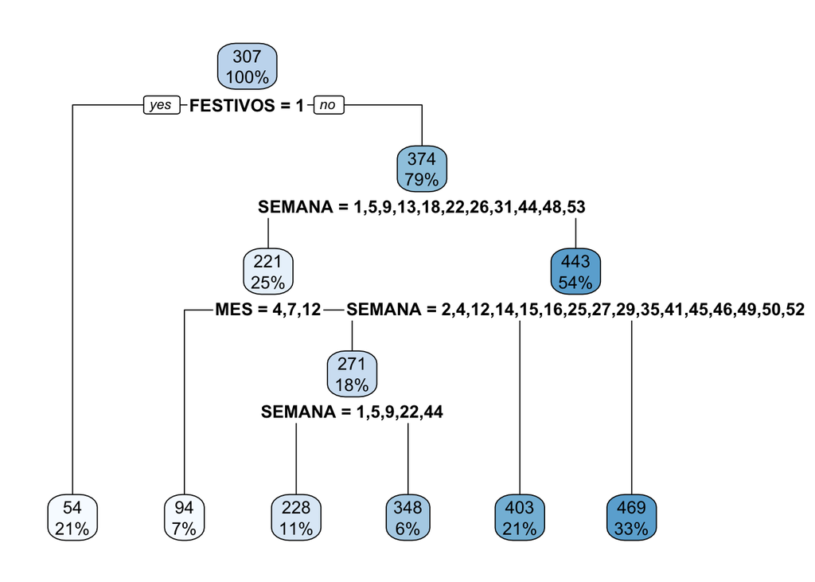

```r
rpart.plot(dt_h)
```

**Ajuste de parámetro de restricción para el árbol regresor**

Se realiza una búsqueda de los parámetros óptimos de minsplit y maxdepth para el árbol regresor:

En la siguiente gráfica se puede observar el numero optimo de nodos identificado por el modelo que reduce el error asociado. Este sera el punto de partida para definir entre que valores puede variar el parámetro de profundidad del árbol. Vemos que el árbol inicial tiene 5 divisiones y 6 nodos finales.

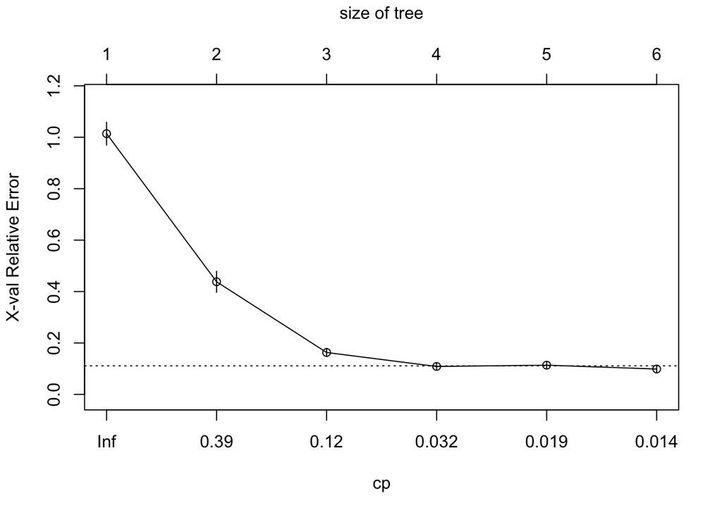

```r
plotcp(dt_h)
```

```r
dt_sd2 <- rpart(
    formula = HERIDOS.R ~ .,
    data    = heridos_train,
    method  = "anova",
    control = list(cp = 0, xval = 10)
)
```

El error de validación cruzada asociado es de 0.11, este valor se puede mejorar en el proceso de tuning

```
##           CP nsplit  rel error     xerror       xstd
## 1 0.56577887      0 1.00000000 1.01385053 0.04446196
## 2 0.27556583      1 0.43422113 0.43801427 0.04070608
## 3 0.05156987      2 0.15865530 0.16305001 0.01594435
## 4 0.01938167      3 0.10708543 0.10862811 0.01098020
## 5 0.01896086      4 0.08770375 0.11372037 0.01180316
## 6 0.01000000      5 0.06874289 0.09873479 0.01223365
```

El siguiente código define una función grid para la búsqueda de diferentes combinaciones de minsplit y maxdepth. También las funciones que extraen el optimo cp y el mínimo error asociado.

```r
hyper_grid_h <- expand.grid(
  minsplit = seq(5, 30, 1),
  maxdepth = seq(5, 8, 1))

models_h <- list()

for (i in 1:nrow(hyper_grid_h)) {

  # get minsplit, maxdepth values at row i
  minsplit <- hyper_grid_h$minsplit[i]
  maxdepth <- hyper_grid_h$maxdepth[i]

  # train a model and store in the list
  models_h[[i]] <- rpart(
    formula = HERIDOS.R ~ .,
    data    = heridos_train,
    method  = "anova",
    control = list(minsplit = minsplit, maxdepth = maxdepth)
    )
}

# function to get optimal cp
get_cp <- function(x) {
  min    <- which.min(x$cptable[, "xerror"])
  cp <- x$cptable[min, "CP"]
}

# function to get minimum error
get_min_error <- function(x) {
  min    <- which.min(x$cptable[, "xerror"])
  xerror <- x$cptable[min, "xerror"]
}
```

Agregaremos los resultados de la búsqueda a la grilla de hyper-parámetros y filtraremos los 5 valores con error mínimo.

```r
hyper_grid_h %>%
  mutate(
    cp    = purrr::map_dbl(models_h, get_cp),
    error = purrr::map_dbl(models_h, get_min_error)
    ) %>%
  arrange(error) %>%
  top_n(-5, wt = error)
```

| minsplit | maxdepth | cp | error |
| --- | --- | --- | --- |
| 24 | 7 | 0.01 | 0.08658002 |
| 22 | 5 | 0.01 | 0.09063191 |
| 30 | 5 | 0.01 | 0.09064288 |
| 5 | 8 | 0.01 | 0.09152578 |
| 24 | 5 | 0.01 | 0.09155841 |

Vemos que el error se redujo a 0.0865, lo cual indica mejores modelos en comparación con el modelo inicial. Se entrena el árbol regresor con las combinaciones que encabezan los resultados anteriores:

```r
optimal_tree_h <- rpart(
    formula = HERIDOS.R ~ .,
    data    = heridos_train,
    method  = "anova",
    control = list(minsplit = 24, maxdepth = 7, cp = 0.01)
    )
```

**Métricas de Bondad para el mejor árbol regresor**

```r
heridos_test$MES <- as.factor(heridos_test$MES)
heridos_test$SEMANA <- as.factor(heridos_test$SEMANA)


pred_dt_train = predict(optimal_tree_h, newdata=heridos_train)
pred_dt_test = predict(optimal_tree_h, newdata=heridos_test)


dt_h_op1 <- data.frame(RMSE_Train = RMSE(pred_dt_train, heridos_train$HERIDOS.R),
                    Rsquared_Train = R2(pred_dt_train, heridos_train$HERIDOS.R),
                    RMSE_Test = RMSE(pred_dt_test, heridos_test$HERIDOS.R),
                    Rsquared_Test = R2(pred_dt_test, heridos_test$HERIDOS.R))


dt_h_op1
```

| RMSE_Train | Rsquared_Train | RMSE_Test | Rsquared_Test |
| --- | --- | --- | --- |
| 45.47784 | 0.9312571 | 57.71568 | 0.9249343 |

**Mejor árbol regresor obtenido**

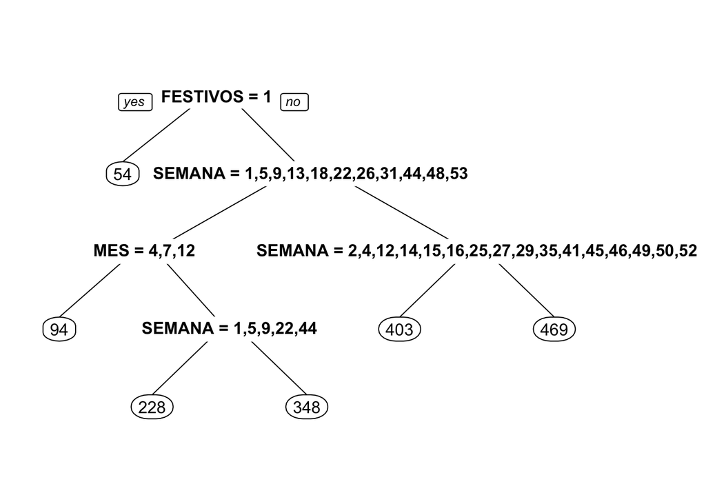

```r
library(rpart.plot)
prp(optimal_tree_h)
```

## 5.3 **Random Forest**

**Entrenamiento del modelo**

Se toma el modelo mas simple, a partir de este se realizará una búsqueda tipo grid search de los hiper parámetros óptimos, mediante el uso de la librería Range. Se analizaron en total 96 modelos diferentes con variaciones en mtry, mínimo tamaño de muestras en el nodo, y tamaño de la muestra.

```r
set.seed(101)
rf_h = randomForest(HERIDOS.R ~ ., data = heridos_train)
rf_h
```

```
##
## Call:
##  randomForest(formula = HERIDOS.R ~ ., data = heridos_train)
##                Type of random forest: regression
##                      Number of trees: 500
## No. of variables tried at each split: 1
##
##           Mean of squared residuals: 4804.987
##                     % Var explained: 84.03
```

Inicialmente, observamos que la varianza explicada por el modelo es del 84,03 %.

**Este gráfico muestra el error vs. el número de árboles**

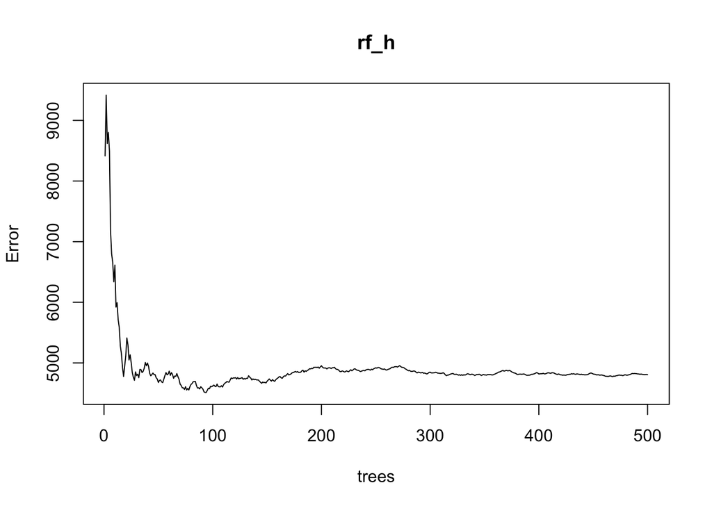

**Afinamiento del modelo Random Forest**

Se define la siguiente grilla de búsqueda:

```r
set.seed(101)
# hyperparameter grid search
hyper_grid_rf <- expand.grid(
  mtry       = seq(1, 3, by = 1),
  node_size  = seq(7, 21, by = 2),
  sampe_size = c(.55, .632, .70, .80),
  OOB_RMSE   = 0
)

# total number of combinations
#(hyper_grid_rf)
```

Se utiliza la librería Ranger para la búsqueda de los mejores hyper parámetros:

```r
for(i in 1:nrow(hyper_grid_rf)) {

  # train model
  model <- ranger(
    formula         = HERIDOS.R ~ .,
    data            = heridos_train,
    num.trees       = 500,
    mtry            = hyper_grid_rf$mtry[i],
    min.node.size   = hyper_grid_rf$node_size[i],
    sample.fraction = hyper_grid_rf$sampe_size[i],
    seed            = 101
  )

  # add OOB error to grid
  hyper_grid_rf$OOB_RMSE[i] <- sqrt(model$prediction.error)
}

hyper_grid_rf %>%
  dplyr::arrange(OOB_RMSE) %>%
  head(10)
```

|  | mtry | node_size | sampe_size | OOB_RMSE |
| --- | --- | --- | --- | --- |
| 1 | 3 | 7 | 0.800 | 56.48608 |
| 2 | 2 | 7 | 0.800 | 58.63821 |
| 3 | 3 | 7 | 0.700 | 58.87972 |
| 4 | 3 | 9 | 0.800 | 59.31579 |
| 5 | 2 | 9 | 0.800 | 60.65641 |
| 6 | 3 | 7 | 0.632 | 61.10185 |
| 7 | 3 | 11 | 0.800 | 61.56474 |
| 8 | 3 | 9 | 0.700 | 61.63314 |
| 9 | 2 | 7 | 0.700 | 62.07179 |
| 10 | 2 | 11 | 0.800 | 63.80724 |

```r
set.seed(101)
mejorRandomforest <- randomForest(HERIDOS.R ~., data = heridos_train, mtry = 3 ,
                                  nodesize = 11, ntree = 500, importance = TRUE)
mejorRandomforest
```

```
##
## Call:
##  randomForest(formula = HERIDOS.R ~ ., data = heridos_train, mtry = 3,      nodesize = 11, ntree = 500, importance = TRUE)
##                Type of random forest: regression
##                      Number of trees: 500
## No. of variables tried at each split: 3
##
##           Mean of squared residuals: 2618.751
##                     % Var explained: 91.3
```

Con la función importance() se extrae la importancia de las variables.

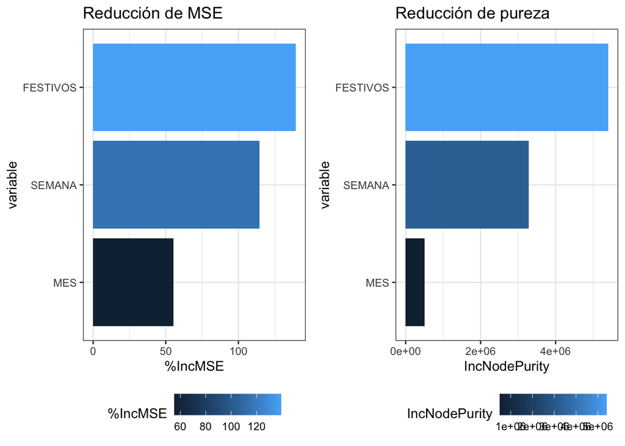

```r
library(tidyverse)
library(ggpubr)
importancia_pred <- as.data.frame(importance(mejorRandomforest, scale = TRUE))
importancia_pred <- rownames_to_column(importancia_pred, var = "variable")
p1 <- ggplot(data = importancia_pred, aes(x = reorder(variable, `%IncMSE`),
                                          y = `%IncMSE`,
                                          fill = `%IncMSE`)) +
    labs(x = "variable", title = "Reducción de MSE") +
    geom_col() +
    coord_flip() +
    theme_bw() +
    theme(legend.position = "bottom")

p2 <- ggplot(data = importancia_pred, aes(x = reorder(variable, IncNodePurity),
                                          y = IncNodePurity,
                                          fill = IncNodePurity)) +
    labs(x = "variable", title = "Reducción de pureza") +
    geom_col() +
    coord_flip() +
    theme_bw() +
    theme(legend.position = "bottom")
ggarrange(p1, p2)
```

**Métricas de bondad para modelo de Random Forest**

```r
pred_randomForest_t <- predict(mejorRandomforest, heridos_train)
pred_randomForest <- predict(mejorRandomforest, heridos_test)

dt_rf_1 <- data.frame(RMSE_Train = RMSE(pred_randomForest_t, heridos_train$HERIDOS.R),
                    Rsquared_Train = R2(pred_randomForest_t, heridos_train$HERIDOS.R),
                    RMSE_Test = RMSE(pred_randomForest, heridos_test$HERIDOS.R),
                    Rsquared_Test = R2(pred_randomForest, heridos_test$HERIDOS.R))


dt_rf_1
```

| RMSE_Train | Rsquared_Train | RMSE_Test | Rsquared_Test |
| --- | --- | --- | --- |
| 38.01704 | 0.9523667 | 51.69021 | 0.9465184 |

Observamos que los R-squared para entrenamiento y validación son mas altos en comparación con los modelos de regresión lineal y Árbol regresor y su variación es mínima. El RMSE presenta una variación del 36%, a pesar de que puede indicar sobre ajuste, por las métricas obtenidas en el R-squared, se define como mejor modelo.